# Practical Lab 10

#### `4. Image Pixel Intensity Distribution`

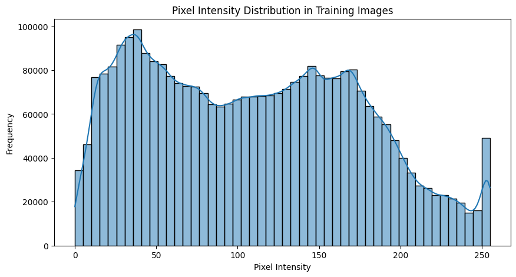

```python
def plot_pixel_distribution(images, title):
    pixel_values = images.numpy().flatten()
    plt.figure(figsize=(10, 5))
    sns.histplot(pixel_values, bins=50, kde=True)
    plt.title(f'Pixel Intensity Distribution in {title}')
    plt.xlabel('Pixel Intensity')
    plt.ylabel('Frequency')
    plt.show()

for images, _ in train_dataset.take(1):
    plot_pixel_distribution(images, "Training Images")
```

#### `5. Explore Image Augmentation`

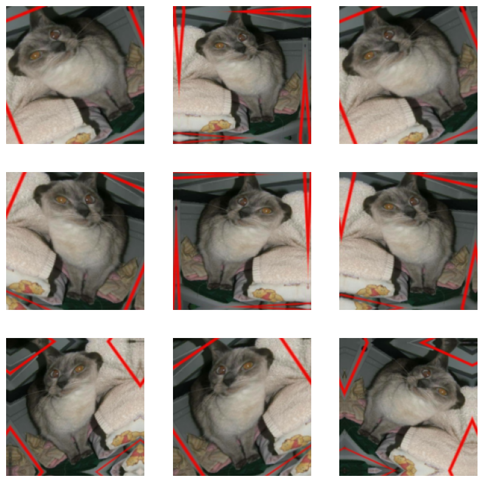

```python
data_augmentation = tf.keras.Sequential([
  tf.keras.layers.RandomFlip('horizontal'),
  tf.keras.layers.RandomRotation(0.1),
  tf.keras.layers.RandomZoom(0.1),
])

plt.figure(figsize=(10, 10))
for images, _ in train_dataset.take(1):
    for i in range(9):
        augmented_images = data_augmentation(images)
        ax = plt.subplot(3, 3, i + 1)
        plt.imshow(augmented_images[0].numpy().astype("uint8"))
        plt.axis("off")
```

#### `6. data batch shape & labels batch shape`

```python
for data_batch, labels_batch in train_dataset:
    print("data batch shape:", data_batch.shape)
    print("labels batch shape:", labels_batch.shape)
    break
```

```
data batch shape: (32, 180, 180, 3)
labels batch shape: (32,)
```

##### **Q3 Train two networks (make sure to use callbacks to save the best model version as done in lab 9):**

#### 3.1 Define a Neural Network of your choice

```python
# Define the model
model_vanilla = models.Sequential([
    layers.Conv2D(32, (3, 3), activation='relu', input_shape=(180, 180, 3)),
    layers.MaxPooling2D((2, 2)),
    layers.Conv2D(64, (3, 3), activation='relu'),
    layers.MaxPooling2D((2, 2)),
    layers.Conv2D(128, (3, 3), activation='relu'),
    layers.MaxPooling2D((2, 2)),
    layers.Flatten(),
    layers.Dense(512, activation='relu'),
    layers.Dense(1, activation='sigmoid')
])
```

```python
model_vanilla.summary()
```

```
Model: "sequential_1"
```

```
┏━━━━━━━━━━━━━━━━━━━━━━━━━━━━━━━━━┳━━━━━━━━━━━━━━━━━━━━━━━━┳━━━━━━━━━━━━━━━┓
┃ Layer (type)                    ┃ Output Shape           ┃       Param # ┃
┡━━━━━━━━━━━━━━━━━━━━━━━━━━━━━━━━━╇━━━━━━━━━━━━━━━━━━━━━━━━╇━━━━━━━━━━━━━━━┩
│ conv2d (Conv2D)                 │ (None, 178, 178, 32)   │           896 │
├─────────────────────────────────┼────────────────────────┼───────────────┤
│ max_pooling2d (MaxPooling2D)    │ (None, 89, 89, 32)     │             0 │
├─────────────────────────────────┼────────────────────────┼───────────────┤
│ conv2d_1 (Conv2D)               │ (None, 87, 87, 64)     │        18,496 │
├─────────────────────────────────┼────────────────────────┼───────────────┤
│ max_pooling2d_1 (MaxPooling2D)  │ (None, 43, 43, 64)     │             0 │
├─────────────────────────────────┼────────────────────────┼───────────────┤
│ conv2d_2 (Conv2D)               │ (None, 41, 41, 128)    │        73,856 │
├─────────────────────────────────┼────────────────────────┼───────────────┤
│ max_pooling2d_2 (MaxPooling2D)  │ (None, 20, 20, 128)    │             0 │
├─────────────────────────────────┼────────────────────────┼───────────────┤
│ flatten (Flatten)               │ (None, 51200)          │             0 │
├─────────────────────────────────┼────────────────────────┼───────────────┤
│ dense (Dense)                   │ (None, 512)            │    26,214,912 │
├─────────────────────────────────┼────────────────────────┼───────────────┤
│ dense_1 (Dense)                 │ (None, 1)              │           513 │
└─────────────────────────────────┴────────────────────────┴───────────────┘
```

```
 Total params: 26,308,673 (100.36 MB)
```

```
 Trainable params: 26,308,673 (100.36 MB)
```

```
 Non-trainable params: 0 (0.00 B)
```

```python
model_vanilla.compile(optimizer='adam',
              loss='binary_crossentropy',
              metrics=['accuracy'])
```

```python
model_vanilla.summary()
```

```
Model: "sequential_1"
```

```
┏━━━━━━━━━━━━━━━━━━━━━━━━━━━━━━━━━┳━━━━━━━━━━━━━━━━━━━━━━━━┳━━━━━━━━━━━━━━━┓
┃ Layer (type)                    ┃ Output Shape           ┃       Param # ┃
┡━━━━━━━━━━━━━━━━━━━━━━━━━━━━━━━━━╇━━━━━━━━━━━━━━━━━━━━━━━━╇━━━━━━━━━━━━━━━┩
│ conv2d (Conv2D)                 │ (None, 178, 178, 32)   │           896 │
├─────────────────────────────────┼────────────────────────┼───────────────┤
│ max_pooling2d (MaxPooling2D)    │ (None, 89, 89, 32)     │             0 │
├─────────────────────────────────┼────────────────────────┼───────────────┤
│ conv2d_1 (Conv2D)               │ (None, 87, 87, 64)     │        18,496 │
├─────────────────────────────────┼────────────────────────┼───────────────┤
│ max_pooling2d_1 (MaxPooling2D)  │ (None, 43, 43, 64)     │             0 │
├─────────────────────────────────┼────────────────────────┼───────────────┤
│ conv2d_2 (Conv2D)               │ (None, 41, 41, 128)    │        73,856 │
├─────────────────────────────────┼────────────────────────┼───────────────┤
│ max_pooling2d_2 (MaxPooling2D)  │ (None, 20, 20, 128)    │             0 │
├─────────────────────────────────┼────────────────────────┼───────────────┤
│ flatten (Flatten)               │ (None, 51200)          │             0 │
├─────────────────────────────────┼────────────────────────┼───────────────┤
│ dense (Dense)                   │ (None, 512)            │    26,214,912 │
├─────────────────────────────────┼────────────────────────┼───────────────┤
│ dense_1 (Dense)                 │ (None, 1)              │           513 │
└─────────────────────────────────┴────────────────────────┴───────────────┘
```

```
 Total params: 78,926,021 (301.08 MB)
```

```
 Trainable params: 26,308,673 (100.36 MB)
```

```
 Non-trainable params: 0 (0.00 B)
```

```
 Optimizer params: 52,617,348 (200.72 MB)
```

```python
callbacks = [
    tf.keras.callbacks.ModelCheckpoint(
        filepath="C:\\Foundations_of_Machine_Learning_Frameworks_lab\\Labs\\lab1\\CSCN8010-labs-simardeep-singh\\convnet_from_scratch.keras",
        save_best_only=True,
        monitor="val_loss")
]
```

```python
history = model_vanilla.fit(
    train_dataset,
    epochs=30,
    validation_data=validation_dataset,
    callbacks=callbacks)
```

```
63/63 ━━━━━━━━━━━━━━━━━━━━ 52s 713ms/step - accuracy: 0.5268 - loss: 141.6904 - val_accuracy: 0.5860 - val_loss: 0.6695
63/63 ━━━━━━━━━━━━━━━━━━━━ 42s 663ms/step - accuracy: 0.5929 - loss: 0.6502 - val_accuracy: 0.5870 - val_loss: 0.6599
63/63 ━━━━━━━━━━━━━━━━━━━━ 41s 649ms/step - accuracy: 0.6718 - loss: 0.6041 - val_accuracy: 0.5970 - val_loss: 0.7045
63/63 ━━━━━━━━━━━━━━━━━━━━ 38s 603ms/step - accuracy: 0.7490 - loss: 0.4913 - val_accuracy: 0.6020 - val_loss: 0.7019
63/63 ━━━━━━━━━━━━━━━━━━━━ 38s 606ms/step - accuracy: 0.8157 - loss: 0.3873 - val_accuracy: 0.6270 - val_loss: 0.8714
63/63 ━━━━━━━━━━━━━━━━━━━━ 38s 609ms/step - accuracy: 0.9073 - loss: 0.2222 - val_accuracy: 0.6220 - val_loss: 1.0958
63/63 ━━━━━━━━━━━━━━━━━━━━ 38s 603ms/step - accuracy: 0.9731 - loss: 0.0944 - val_accuracy: 0.6370 - val_loss: 1.2672
63/63 ━━━━━━━━━━━━━━━━━━━━ 38s 603ms/step - accuracy: 0.9874 - loss: 0.0506 - val_accuracy: 0.6270 - val_loss: 1.4172
63/63 ━━━━━━━━━━━━━━━━━━━━ 38s 608ms/step - accuracy: 0.9868 - loss: 0.0490 - val_accuracy: 0.6000 - val_loss: 1.4339
63/63 ━━━━━━━━━━━━━━━━━━━━ 38s 609ms/step - accuracy: 0.8951 - loss: 0.2670 - val_accuracy: 0.5910 - val_loss: 1.7604
63/63 ━━━━━━━━━━━━━━━━━━━━ 38s 608ms/step - accuracy: 0.9732 - loss: 0.0987 - val_accuracy: 0.6300 - val_loss: 1.6559
63/63 ━━━━━━━━━━━━━━━━━━━━ 38s 610ms/step - accuracy: 0.9851 - loss: 0.0568 - val_accuracy: 0.6310 - val_loss: 1.6307
63/63 ━━━━━━━━━━━━━━━━━━━━ 38s 606ms/step - accuracy: 0.9976 - loss: 0.0211 - val_accuracy: 0.6340 - val_loss: 2.1102
63/63 ━━━━━━━━━━━━━━━━━━━━ 38s 607ms/step - accuracy: 0.9999 - loss: 0.0050 - val_accuracy: 0.6170 - val_loss: 2.2682
63/63 ━━━━━━━━━━━━━━━━━━━━ 38s 603ms/step - accuracy: 0.9996 - loss: 0.0047 - val_accuracy: 0.6280 - val_loss: 2.4376
63/63 ━━━━━━━━━━━━━━━━━━━━ 38s 604ms/step - accuracy: 0.9987 - loss: 0.0080 - val_accuracy: 0.6230 - val_loss: 2.5945
63/63 ━━━━━━━━━━━━━━━━━━━━ 40s 628ms/step - accuracy: 0.9963 - loss: 0.0150 - val_accuracy: 0.6040 - val_loss: 2.9584
63/63 ━━━━━━━━━━━━━━━━━━━━ 39s 624ms/step - accuracy: 0.9868 - loss: 0.0350 - val_accuracy: 0.6090 - val_loss: 2.7198
63/63 ━━━━━━━━━━━━━━━━━━━━ 40s 627ms/step - accuracy: 0.9916 - loss: 0.0165 - val_accuracy: 0.6400 - val_loss: 2.7411
63/63 ━━━━━━━━━━━━━━━━━━━━ 39s 622ms/step - accuracy: 0.9986 - loss: 0.0044 - val_accuracy: 0.6150 - val_loss: 2.8461
63/63 ━━━━━━━━━━━━━━━━━━━━ 39s 623ms/step - accuracy: 1.0000 - loss: 0.0017 - val_accuracy: 0.6170 - val_loss: 3.0331
63/63 ━━━━━━━━━━━━━━━━━━━━ 39s 622ms/step - accuracy: 1.0000 - loss: 1.8213e-04 - val_accuracy: 0.6150 - val_loss: 3.1155
63/63 ━━━━━━━━━━━━━━━━━━━━ 40s 635ms/step - accuracy: 1.0000 - loss: 1.3995e-04 - val_accuracy: 0.6120 - val_loss: 3.1461
63/63 ━━━━━━━━━━━━━━━━━━━━ 39s 622ms/step - accuracy: 1.0000 - loss: 1.0737e-04 - val_accuracy: 0.6100 - val_loss: 3.1451
63/63 ━━━━━━━━━━━━━━━━━━━━ 39s 624ms/step - accuracy: 1.0000 - loss: 9.6112e-05 - val_accuracy: 0.6130 - val_loss: 3.3603
63/63 ━━━━━━━━━━━━━━━━━━━━ 39s 624ms/step - accuracy: 1.0000 - loss: 7.7904e-05 - val_accuracy: 0.6150 - val_loss: 3.1470
63/63 ━━━━━━━━━━━━━━━━━━━━ 40s 628ms/step - accuracy: 1.0000 - loss: 5.8487e-05 - val_accuracy: 0.6150 - val_loss: 3.2718
63/63 ━━━━━━━━━━━━━━━━━━━━ 39s 625ms/step - accuracy: 1.0000 - loss: 5.3512e-05 - val_accuracy: 0.6140 - val_loss: 3.2018
63/63 ━━━━━━━━━━━━━━━━━━━━ 40s 628ms/step - accuracy: 1.0000 - loss: 4.4434e-05 - val_accuracy: 0.6140 - val_loss: 3.2449
63/63 ━━━━━━━━━━━━━━━━━━━━ 40s 626ms/step - accuracy: 1.0000 - loss: 3.9393e-05 - val_accuracy: 0.6130 - val_loss: 3.3234
```

#### 3.2 Fine-Tune VGG16 (pre-trained on imagenet). Make sure to use validation to test for over-fitting. Plot the appropriate graph

```python
base_model = VGG16(weights='imagenet', include_top=False, input_shape=(180, 180, 3))
base_model.trainable = False
```

```
Downloading data from https://storage.googleapis.com/tensorflow/keras-applications/vgg16/vgg16_weights_tf_dim_ordering_tf_kernels_notop.h5
58889256/58889256 ━━━━━━━━━━━━━━━━━━━━ 1s 0us/step
```

```python
model = models.Sequential([
    base_model,
    layers.Flatten(),
    layers.Dense(256, activation='relu'),
    layers.Dropout(0.5),
    layers.Dense(1, activation='sigmoid')
])
```

```python
model.compile(optimizer=optimizers.Adam(learning_rate=0.0001),
              loss='binary_crossentropy',
              metrics=['accuracy'])
```

```python
callbacks = [
    tf.keras.callbacks.ModelCheckpoint(
        filepath="C:\\Foundations_of_Machine_Learning_Frameworks_lab\\Labs\\lab1\\CSCN8010-labs-simardeep-singh\\vgg16_fine_tuned.keras",
        save_best_only=True,
        monitor="val_loss")
]
```

```python
history = model.fit(
    train_dataset,
    epochs=30,
    validation_data=validation_dataset,
    callbacks=callbacks)
```

```
63/63 ━━━━━━━━━━━━━━━━━━━━ 192s 3s/step - accuracy: 0.7758 - loss: 4.2195 - val_accuracy: 0.9430 - val_loss: 0.7020
63/63 ━━━━━━━━━━━━━━━━━━━━ 185s 3s/step - accuracy: 0.9526 - loss: 0.6157 - val_accuracy: 0.9460 - val_loss: 0.6849
63/63 ━━━━━━━━━━━━━━━━━━━━ 184s 3s/step - accuracy: 0.9842 - loss: 0.1672 - val_accuracy: 0.9520 - val_loss: 0.6445
63/63 ━━━━━━━━━━━━━━━━━━━━ 186s 3s/step - accuracy: 0.9778 - loss: 0.1923 - val_accuracy: 0.9440 - val_loss: 0.6255
63/63 ━━━━━━━━━━━━━━━━━━━━ 192s 3s/step - accuracy: 0.9895 - loss: 0.0696 - val_accuracy: 0.9560 - val_loss: 0.4692
63/63 ━━━━━━━━━━━━━━━━━━━━ 192s 3s/step - accuracy: 0.9897 - loss: 0.0802 - val_accuracy: 0.9490 - val_loss: 0.6395
63/63 ━━━━━━━━━━━━━━━━━━━━ 192s 3s/step - accuracy: 0.9866 - loss: 0.1164 - val_accuracy: 0.9550 - val_loss: 0.4864
63/63 ━━━━━━━━━━━━━━━━━━━━ 192s 3s/step - accuracy: 0.9939 - loss: 0.0349 - val_accuracy: 0.9530 - val_loss: 0.4973
63/63 ━━━━━━━━━━━━━━━━━━━━ 192s 3s/step - accuracy: 0.9957 - loss: 0.0216 - val_accuracy: 0.9510 - val_loss: 0.5880
63/63 ━━━━━━━━━━━━━━━━━━━━ 193s 3s/step - accuracy: 0.9997 - loss: 0.0027 - val_accuracy: 0.9520 - val_loss: 0.4453
63/63 ━━━━━━━━━━━━━━━━━━━━ 193s 3s/step - accuracy: 0.9966 - loss: 0.0232 - val_accuracy: 0.9540 - val_loss: 0.4653
63/63 ━━━━━━━━━━━━━━━━━━━━ 192s 3s/step - accuracy: 0.9977 - loss: 0.0018 - val_accuracy: 0.9520 - val_loss: 0.4720
63/63 ━━━━━━━━━━━━━━━━━━━━ 192s 3s/step - accuracy: 0.9979 - loss: 0.0109 - val_accuracy: 0.9550 - val_loss: 0.5050
63/63 ━━━━━━━━━━━━━━━━━━━━ 191s 3s/step - accuracy: 0.9974 - loss: 0.0223 - val_accuracy: 0.9480 - val_loss: 0.5441
63/63 ━━━━━━━━━━━━━━━━━━━━ 192s 3s/step - accuracy: 0.9953 - loss: 0.0208 - val_accuracy: 0.9480 - val_loss: 0.6052
63/63 ━━━━━━━━━━━━━━━━━━━━ 192s 3s/step - accuracy: 0.9977 - loss: 0.0110 - val_accuracy: 0.9500 - val_loss: 0.4956
63/63 ━━━━━━━━━━━━━━━━━━━━ 192s 3s/step - accuracy: 0.9963 - loss: 0.0210 - val_accuracy: 0.9510 - val_loss: 0.4825
63/63 ━━━━━━━━━━━━━━━━━━━━ 192s 3s/step - accuracy: 0.9981 - loss: 0.0088 - val_accuracy: 0.9540 - val_loss: 0.5762
63/63 ━━━━━━━━━━━━━━━━━━━━ 192s 3s/step - accuracy: 0.9980 - loss: 0.0150 - val_accuracy: 0.9540 - val_loss: 0.5325
63/63 ━━━━━━━━━━━━━━━━━━━━ 193s 3s/step - accuracy: 0.9995 - loss: 8.4117e-04 - val_accuracy: 0.9540 - val_loss: 0.5288
63/63 ━━━━━━━━━━━━━━━━━━━━ 215s 3s/step - accuracy: 0.9996 - loss: 0.0026 - val_accuracy: 0.9540 - val_loss: 0.5645
63/63 ━━━━━━━━━━━━━━━━━━━━ 224s 4s/step - accuracy: 0.9992 - loss: 0.0032 - val_accuracy: 0.9550 - val_loss: 0.5285
63/63 ━━━━━━━━━━━━━━━━━━━━ 205s 3s/step - accuracy: 0.9950 - loss: 0.0554 - val_accuracy: 0.9570 - val_loss: 0.5787
63/63 ━━━━━━━━━━━━━━━━━━━━ 193s 3s/step - accuracy: 0.9961 - loss: 0.0213 - val_accuracy: 0.9570 - val_loss: 0.5748
63/63 ━━━━━━━━━━━━━━━━━━━━ 186s 3s/step - accuracy: 0.9985 - loss: 0.0057 - val_accuracy: 0.9580 - val_loss: 0.5438
63/63 ━━━━━━━━━━━━━━━━━━━━ 197s 3s/step - accuracy: 0.9975 - loss: 0.0225 - val_accuracy: 0.9500 - val_loss: 0.7128
63/63 ━━━━━━━━━━━━━━━━━━━━ 188s 3s/step - accuracy: 0.9985 - loss: 0.0062 - val_accuracy: 0.9580 - val_loss: 0.5498
63/63 ━━━━━━━━━━━━━━━━━━━━ 174s 3s/step - accuracy: 0.9964 - loss: 0.0235 - val_accuracy: 0.9590 - val_loss: 0.6154
63/63 ━━━━━━━━━━━━━━━━━━━━ 191s 3s/step - accuracy: 0.9990 - loss: 0.0020 - val_accuracy: 0.9500 - val_loss: 0.6072
63/63 ━━━━━━━━━━━━━━━━━━━━ 198s 3s/step - accuracy: 0.9969 - loss: 0.0524 - val_accuracy: 0.9560 - val_loss: 0.6438
```

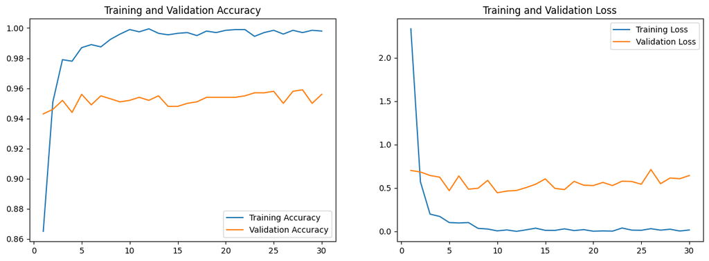

```python
acc = history.history['accuracy']
val_acc = history.history['val_accuracy']
loss = history.history['loss']
val_loss = history.history['val_loss']

epochs = range(1, len(acc) + 1)

plt.figure(figsize=(15, 5))
plt.subplot(1, 2, 1)
plt.plot(epochs, acc, label='Training Accuracy')
plt.plot(epochs, val_acc, label='Validation Accuracy')
plt.title('Training and Validation Accuracy')
plt.legend()

plt.subplot(1, 2, 2)
plt.plot(epochs, loss, label='Training Loss')
plt.plot(epochs, val_loss, label='Validation Loss')
plt.title('Training and Validation Loss')
plt.legend()

plt.show()
```

##### `Loading best models`

```python
vanilla_model_path = 'C:\\Foundations_of_Machine_Learning_Frameworks_lab\\Labs\\lab1\\CSCN8010-labs-simardeep-singh\\convnet_from_scratch.keras'
vanilla_model = tf.keras.models.load_model(vanilla_model_path)

# UNABLE TO LOAD VGG16 MODEL
```

#### `Accuracy`

```python
test_loss, test_accuracy = vanilla_model.evaluate(test_dataset)
print(f"Test Accuracy: {test_accuracy:.3f}")
```

```
63/63 ━━━━━━━━━━━━━━━━━━━━ 12s 158ms/step - accuracy: 0.6011 - loss: 0.6590
Test Accuracy: 0.595
```

#### `Confusion Metrics`

```python
import numpy as np
from sklearn.metrics import classification_report, confusion_matrix

# Get true labels and model predictions
y_true = np.concatenate([labels.numpy() for _, labels in test_dataset])
y_pred = np.round(vanilla_model.predict(test_dataset)).flatten()

# Compute metrics
print("Confusion Matrix:")
print(confusion_matrix(y_true, y_pred))
print("\nClassification Report:")
print(classification_report(y_true, y_pred, target_names=['Class 0', 'Class 1']))
```

```
63/63 ━━━━━━━━━━━━━━━━━━━━ 7s 112ms/step
Confusion Matrix:
[[449 551]
 [464 536]]

Classification Report:
              precision    recall  f1-score   support

     Class 0       0.49      0.45      0.47      1000
     Class 1       0.49      0.54      0.51      1000

    accuracy                           0.49      2000
   macro avg       0.49      0.49      0.49      2000
weighted avg       0.49      0.49      0.49      2000
```

#### `precision, recall, F1-score`

```python
import numpy as np


y_true = np.concatenate([y for _, y in test_dataset], axis=0)
y_pred_probs = vanilla_model.predict(test_dataset)

threshold = 0.5
y_pred = (y_pred_probs > threshold).astype(int)
from sklearn.metrics import precision_score, recall_score, f1_score


precision = precision_score(y_true, y_pred)
recall = recall_score(y_true, y_pred)
f1 = f1_score(y_true, y_pred)

print(f'Precision: {precision:.3f}')
print(f'Recall: {recall:.3f}')
print(f'F1-Score: {f1:.3f}')
```

```
63/63 ━━━━━━━━━━━━━━━━━━━━ 8s 120ms/step
Precision: 0.481
Recall: 0.523
F1-Score: 0.501
```

**-The model was evaluated over 63 batches, taking an average of 120 milliseconds per step, totaling approximately 8 seconds for the complete evaluation.**

**-Precision: 0.481 - This means that when the model predicts the positive class, it is correct about 48.1% of the time. This is an indicator of the quality of the positive class predictions.**

**-Recall: 0.523 - Signifying that the model correctly identifies 52.3% of all actual positive instances. This measures the model's ability to detect positive instances.**

**-F1-Score: 0.501 - An F1-score of 0.501 suggests the model has moderate accuracy, with a balanced trade-off between precision and recall.**

#### `precision-recall curve.`

```
63/63 ━━━━━━━━━━━━━━━━━━━━ 7s 114ms/step
```

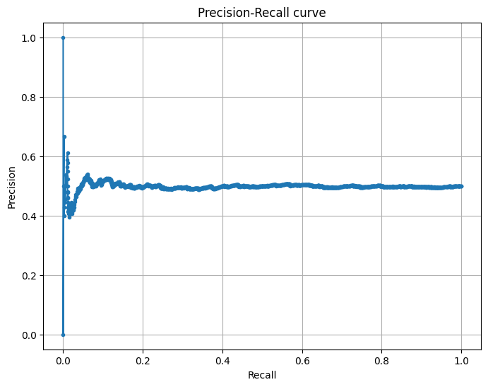

```python
import matplotlib.pyplot as plt
from sklearn.metrics import precision_recall_curve
import numpy as np


y_scores = vanilla_model.predict(test_dataset)
y_true = np.concatenate([y for x, y in test_dataset], axis=0)

precision, recall, thresholds = precision_recall_curve(y_true, y_scores)

plt.figure(figsize=(8, 6))
plt.plot(recall, precision, marker='.')
plt.title('Precision-Recall curve')
plt.xlabel('Recall')
plt.ylabel('Precision')
plt.grid(True)
plt.show()
```

**At the beginning of the threshold spectrum, we observe that the precision starts at 0.5 with a recall of 1. This indicates that when classifying almost all samples as positive, half are correct (since precision is the fraction of true positives among all predicted positives), and all true positives are captured (since recall is the fraction of true positives among all actual positives). As thresholds increase, both precision and recall show variations, which is expected as the classification criteria become stricter.**

### `CONCLUSION`

1. Accuracy: the model seems to demonstrate moderate effectiveness. An accuracy around 50-60% was indicated, which suggests that the model performs slightly better than random guessing but is not highly reliable for making accurate predictions.
2. Confusion Matrix: The confusion matrix shows a relatively even distribution of true positives (TP), false positives (FP), true negatives (TN), and false negatives (FN). However, the model seems to struggle equally with both classes, as indicated by the high number of false positives and false negatives. This suggests that the model does not strongly favor one class over the other but also fails to effectively distinguish between them in many cases.
3. Precision and Recall: The model's precision and recall were low (around 0.48 and 0.52, respectively). This indicates that when the model predicts an instance as positive, it is correct less than half the time. Similarly, the model identifies just over half of all actual positive instances. These values suggest a lack of confidence in the model’s predictive power.
4. F1-Score: The F1-score, being a harmonic mean of precision and recall, was also moderate (around 0.50). This score confirms that the model has a balanced but mediocre performance regarding precision and recall. The balance is not due to high performance but rather to a similar level of low performance on both metrics.
5. Precision-Recall Curve: The precision-recall curve provide insight into the trade-off between precision and recall at different thresholds. However the curve suggested a moderate starting performance which deteriorates with increasing thresholds.

**The model exhibits average performance, struggling to effectively differentiate between the classes with significant precision or recall. Its predictive power is marginally better than random chance but falls short of a desirable or reliable predictive model. The similar low rates of precision and recall indicate that there is no significant bias towards one class but rather a general difficulty in classification.**